# 16. 작업 1유형 - 5

```python
import pandas as pd
df =pd.read_csv('https://raw.githubusercontent.com/Datamanim/datarepo/main/happy2/happiness.csv',encoding='utf-8')
df
```

|  | 행복랭킹 | 나라명 | 점수 | 상대GDP | 사회적지원 | 행복기대치 | 선택의 자유도 | 관대함 | 부패에 대한인식 | 년도 |
| --- | --- | --- | --- | --- | --- | --- | --- | --- | --- | --- |
| 0 | 1 | Finland | 7.769 | 1.340 | 1.587 | 0.986 | 0.596 | 0.153 | 0.393 | 2019 |
| 1 | 2 | Denmark | 7.600 | 1.383 | 1.573 | 0.996 | 0.592 | 0.252 | 0.410 | 2019 |
| 2 | 3 | Norway | 7.554 | 1.488 | 1.582 | 1.028 | 0.603 | 0.271 | 0.341 | 2019 |
| 3 | 4 | Iceland | 7.494 | 1.380 | 1.624 | 1.026 | 0.591 | 0.354 | 0.118 | 2019 |
| 4 | 5 | Netherlands | 7.488 | 1.396 | 1.522 | 0.999 | 0.557 | 0.322 | 0.298 | 2019 |
| ... | ... | ... | ... | ... | ... | ... | ... | ... | ... | ... |
| 307 | 152 | Yemen | 3.355 | 0.442 | 1.073 | 0.343 | 0.244 | 0.083 | 0.064 | 2018 |
| 308 | 153 | Tanzania | 3.303 | 0.455 | 0.991 | 0.381 | 0.481 | 0.270 | 0.097 | 2018 |
| 309 | 154 | South Sudan | 3.254 | 0.337 | 0.608 | 0.177 | 0.112 | 0.224 | 0.106 | 2018 |
| 310 | 155 | Central African Republic | 3.083 | 0.024 | 0.000 | 0.010 | 0.305 | 0.218 | 0.038 | 2018 |
| 311 | 156 | Burundi | 2.905 | 0.091 | 0.627 | 0.145 | 0.065 | 0.149 | 0.076 | 2018 |

312 rows × 10 columns

## 1. 각년도의 행복랭킹 10위를 차지한 나라의 행복점수의 평균

```python
df[df['행복랭킹']==10].점수.mean()
```

```
7.259
```

## 2. 각년도의 행복랭킹 50위이내의 나라들의 각각의 행복점수 평균을 데이터프레임으로 표시

```python
df[df['행복랭킹']<=50][['년도','점수']].groupby('년도').mean()
```

| 년도 | 점수 |
| --- | --- |
| 2018 | 6.64678 |
| 2019 | 6.67002 |

## 3. 2018년도 데이터들만 추출하여 행복점수와 부패에 대한 인식에 대한 상관계수

```python
df[df['년도'] == 2018]['점수'].corr(df[df['년도'] == 2018]['부패에 대한인식'])
```

```
0.40529152271509994
```

## 4. 2018년도와 2019년도의 행복랭킹이 변화하지 않은 나라명의 수

```python
c = 0

for i in range(len(df)):
    for j in range(len(df)):
        if i!=j and df['나라명'].iloc[i] == df['나라명'].iloc[j] and df['행복랭킹'].iloc[i] == df['행복랭킹'].iloc[j]:
            c += 1

c/2
```

```
15.0
```

## 5. 2019년도 데이터들만 추출하여 각변수간 상관계수를 구하고 내림차순으로 정렬한 후 상위 5개를 데이터 프레임으로 출력

```python
z = df[df['년도']==2019].corr(numeric_only=True).unstack().to_frame().reset_index().sort_values(0,ascending=False).dropna()
r = z[z[0]!=1].head(10).drop_duplicates(0).reset_index(drop=True)
r.columns = ['v1','v2','corr']
r
```

|  | v1 | v2 | corr |
| --- | --- | --- | --- |
| 0 | 상대GDP | 행복기대치 | 0.835462 |
| 1 | 점수 | 상대GDP | 0.793883 |
| 2 | 행복기대치 | 점수 | 0.779883 |
| 3 | 점수 | 사회적지원 | 0.777058 |
| 4 | 사회적지원 | 상대GDP | 0.754906 |

## 6. 각 년도별 하위 행복점수의 하위 5개 국가의 평균 행복점수

```python
df.set_index(['년도','나라명']).sort_values(['년도','행복랭킹'],ascending=False).점수.groupby('년도').head().groupby('년도').mean().to_frame()
```

| 년도 | 점수 |
| --- | --- |
| 2018 | 3.1800 |
| 2019 | 3.1408 |

```python
df.groupby('년도').tail().groupby('년도').mean(numeric_only=True)[['점수']]
```

| 년도 | 점수 |
| --- | --- |
| 2018 | 3.1800 |
| 2019 | 3.1408 |

## 7. 2019년 데이터를 추출하고 해당데이터의 상대 GDP 평균 이상의 나라들과 평균 이하의 나라들의 행복점수 평균을 각각 구하고 그 차이값을 출력

```python
df[df['년도']==2019]
```

|  | 행복랭킹 | 나라명 | 점수 | 상대GDP | 사회적지원 | 행복기대치 | 선택의 자유도 | 관대함 | 부패에 대한인식 | 년도 |
| --- | --- | --- | --- | --- | --- | --- | --- | --- | --- | --- |
| 0 | 1 | Finland | 7.769 | 1.340 | 1.587 | 0.986 | 0.596 | 0.153 | 0.393 | 2019 |
| 1 | 2 | Denmark | 7.600 | 1.383 | 1.573 | 0.996 | 0.592 | 0.252 | 0.410 | 2019 |
| 2 | 3 | Norway | 7.554 | 1.488 | 1.582 | 1.028 | 0.603 | 0.271 | 0.341 | 2019 |
| 3 | 4 | Iceland | 7.494 | 1.380 | 1.624 | 1.026 | 0.591 | 0.354 | 0.118 | 2019 |
| 4 | 5 | Netherlands | 7.488 | 1.396 | 1.522 | 0.999 | 0.557 | 0.322 | 0.298 | 2019 |
| ... | ... | ... | ... | ... | ... | ... | ... | ... | ... | ... |
| 151 | 152 | Rwanda | 3.334 | 0.359 | 0.711 | 0.614 | 0.555 | 0.217 | 0.411 | 2019 |
| 152 | 153 | Tanzania | 3.231 | 0.476 | 0.885 | 0.499 | 0.417 | 0.276 | 0.147 | 2019 |
| 153 | 154 | Afghanistan | 3.203 | 0.350 | 0.517 | 0.361 | 0.000 | 0.158 | 0.025 | 2019 |
| 154 | 155 | Central African Republic | 3.083 | 0.026 | 0.000 | 0.105 | 0.225 | 0.235 | 0.035 | 2019 |
| 155 | 156 | South Sudan | 2.853 | 0.306 | 0.575 | 0.295 | 0.010 | 0.202 | 0.091 | 2019 |

156 rows × 10 columns

```python
df[df['년도']==2019].상대GDP.mean()
```

```
0.905147435897436
```

```python
a = df[(df['년도']==2019) & (df.상대GDP>=df[df['년도']==2019].상대GDP.mean())].점수.mean() #평균 이상
a
```

```
6.0132045454545455
```

```python
b = df[(df['년도']==2019) & (df.상대GDP<=df[df['년도']==2019].상대GDP.mean())].점수.mean() #평균 이하
b
```

```
4.622720588235294
```

```python
a-b
```

```
1.390483957219251
```

## 8. 각년도의 부패에 대한인식을 내림차순 정렬했을때 상위 20개 국가의 부패에 대한인식의 평균

```python
df.sort_values('부패에 대한인식',ascending=False).dropna().groupby('년도').head(20).groupby('년도').mean(numeric_only=True)['부패에 대한인식']
```

```
년도
2018    0.3267
2019    0.3201
Name: 부패에 대한인식, dtype: float64
```

## 9. 2018년도 행복랭킹 50위 이내에 포함됐다가 2019년 50위 밖으로 밀려난 국가의 숫자

```python
df[(df['년도'] == 2018) & (df['행복랭킹'] <=50)]['나라명'].to_list()
```

```
['Finland',
 'Norway',
 'Denmark',
 'Iceland',
 'Switzerland',
 'Netherlands',
 'Canada',
 'New Zealand',
 'Sweden',
 'Australia',
 'United Kingdom',
 'Austria',
 'Costa Rica',
 'Ireland',
 'Germany',
 'Belgium',
 'Luxembourg',
 'United States',
 'Israel',
 'United Arab Emirates',
 'Czech Republic',
 'Malta',
 'France',
 'Mexico',
 'Chile',
 'Taiwan',
 'Panama',
 'Brazil',
 'Argentina',
 'Guatemala',
 'Uruguay',
 'Qatar',
 'Saudi Arabia',
 'Singapore',
 'Malaysia',
 'Spain',
 'Colombia',
 'Trinidad & Tobago',
 'Slovakia',
 'El Salvador',
 'Nicaragua',
 'Poland',
 'Bahrain',
 'Uzbekistan',
 'Kuwait',
 'Thailand',
 'Italy',
 'Ecuador',
 'Belize',
 'Lithuania']
```

```python
df[(df['년도'] == 2019) & (df['행복랭킹'] >=50)]['나라명'].to_list()
```

```
['Ecuador',
 'Kuwait',
 'Thailand',
 'Latvia',
 'South Korea',
 'Estonia',
 'Jamaica',
 'Mauritius',
 'Japan',
 'Honduras',
 'Kazakhstan',
 'Bolivia',
 'Hungary',
 'Paraguay',
 'Northern Cyprus',
 'Peru',
 'Portugal',
 'Pakistan',
 'Russia',
 'Philippines',
 'Serbia',
 'Moldova',
 'Libya',
 'Montenegro',
 'Tajikistan',
 'Croatia',
 'Hong Kong',
 'Dominican Republic',
 'Bosnia and Herzegovina',
 'Turkey',
 'Malaysia',
 'Belarus',
 'Greece',
 'Mongolia',
 'North Macedonia',
 'Nigeria',
 'Kyrgyzstan',
 'Turkmenistan',
 'Algeria',
 'Morocco',
```

[output cut: 52 more lines]

```
 'Comoros',
 'Madagascar',
 'Lesotho',
 'Burundi',
 'Zimbabwe',
 'Haiti',
 'Botswana',
 'Syria',
 'Malawi',
 'Yemen',
 'Rwanda',
 'Tanzania',
 'Afghanistan',
 'Central African Republic',
 'South Sudan']
```

```python
df['나라명'].drop_duplicates().apply(lambda x: x in df[(df['년도'] == 2018) & (df['행복랭킹'] <=50)]['나라명'].to_list() and x in df[(df['년도'] == 2019) & (df['행복랭킹'] >=50)]['나라명'].to_list()).sum()
```

```
4
```

## 10. 2018년,2019년 모두 기록이 있는 나라들 중 년도별 행복점수가 가장 증가한 나라와 그 증가 수치

```python
d = df.pivot(index='나라명',columns='년도',values='점수').dropna()
d
```

| 년도 나라명 | 2018 | 2019 |
| --- | --- | --- |
| Afghanistan | 3.632 | 3.203 |
| Albania | 4.586 | 4.719 |
| Algeria | 5.295 | 5.211 |
| Argentina | 6.388 | 6.086 |
| Armenia | 4.321 | 4.559 |
| ... | ... | ... |
| Venezuela | 4.806 | 4.707 |
| Vietnam | 5.103 | 5.175 |
| Yemen | 3.355 | 3.380 |
| Zambia | 4.377 | 4.107 |
| Zimbabwe | 3.692 | 3.663 |

152 rows × 2 columns

```python
c= d[d[2018]<d[2019]]
c
```

| 년도 나라명 | 2018 | 2019 |
| --- | --- | --- |
| Albania | 4.586 | 4.719 |
| Armenia | 4.321 | 4.559 |
| Austria | 7.139 | 7.246 |
| Azerbaijan | 5.201 | 5.208 |
| Bahrain | 6.105 | 6.199 |
| ... | ... | ... |
| United Arab Emirates | 6.774 | 6.825 |
| United States | 6.886 | 6.892 |
| Uzbekistan | 6.096 | 6.174 |
| Vietnam | 5.103 | 5.175 |
| Yemen | 3.355 | 3.380 |

88 rows × 2 columns

```python
c['diff'] = c[2019]-c[2018]
c
```

| 년도 나라명 | 2018 | 2019 | diff |
| --- | --- | --- | --- |
| Albania | 4.586 | 4.719 | 0.133 |
| Armenia | 4.321 | 4.559 | 0.238 |
| Austria | 7.139 | 7.246 | 0.107 |
| Azerbaijan | 5.201 | 5.208 | 0.007 |
| Bahrain | 6.105 | 6.199 | 0.094 |
| ... | ... | ... | ... |
| United Arab Emirates | 6.774 | 6.825 | 0.051 |
| United States | 6.886 | 6.892 | 0.006 |
| Uzbekistan | 6.096 | 6.174 | 0.078 |
| Vietnam | 5.103 | 5.175 | 0.072 |
| Yemen | 3.355 | 3.380 | 0.025 |

88 rows × 3 columns

```python
c.sort_values('diff',ascending=False).reset_index().rename_axis(None,axis=1).iloc[0,[0,3]].to_frame().T
```

|  | 나라명 | diff |
| --- | --- | --- |
| 0 | Burundi | 0.87 |

## 번외: 분석 및 시각화

```python
df.info()
```

```
<class 'pandas.core.frame.DataFrame'>
RangeIndex: 312 entries, 0 to 311
Data columns (total 10 columns):
 #   Column    Non-Null Count  Dtype
---  ------    --------------  -----
 0   행복랭킹      312 non-null    int64
 1   나라명       312 non-null    object
 2   점수        312 non-null    float64
 3   상대GDP     312 non-null    float64
 4   사회적지원     312 non-null    float64
 5   행복기대치     312 non-null    float64
 6   선택의 자유도   312 non-null    float64
 7   관대함       312 non-null    float64
 8   부패에 대한인식  311 non-null    float64
 9   년도        312 non-null    int64
dtypes: float64(7), int64(2), object(1)
memory usage: 24.5+ KB
```

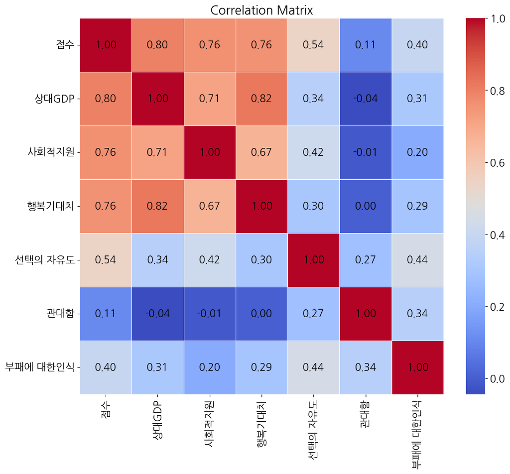

```python
import matplotlib.pyplot as plt
import seaborn as sns
import matplotlib

matplotlib.rcParams['font.family'] = 'NanumGothic' #폰트 지정
matplotlib.rcParams['font.size'] = 15 #폰트 사이즈 지정
matplotlib.rcParams['axes.unicode_minus'] = False #한글 폰트 사용시 마이너스 글자가 깨지는 것 방지

corr_matrix = df.iloc[:,2:9].corr()

plt.figure(figsize=(12, 10))
ax = sns.heatmap(corr_matrix, annot=False, cmap='coolwarm', fmt='.2f', linewidths=0.5)

for i in range(corr_matrix.shape[0]):
    for j in range(corr_matrix.shape[1]):
        plt.text(j + 0.5, i + 0.5, f"{corr_matrix.iloc[i, j]:.2f}",
                 ha='center', va='center', color='black', fontsize=15)

plt.title('Correlation Matrix')
plt.show()
```

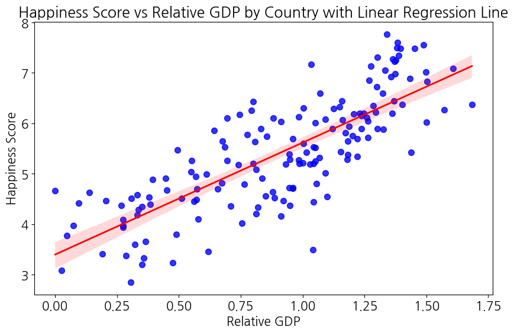

```python
plt.figure(figsize=(10, 6))
sns.regplot(x='상대GDP', y='점수', data=df[df['년도']==2019], scatter_kws={'s': 50, 'color': 'blue'}, line_kws={'color': 'red', 'linewidth': 2})

plt.title('Happiness Score vs Relative GDP by Country with Linear Regression Line')
plt.xlabel('Relative GDP')
plt.ylabel('Happiness Score')

plt.show()
```

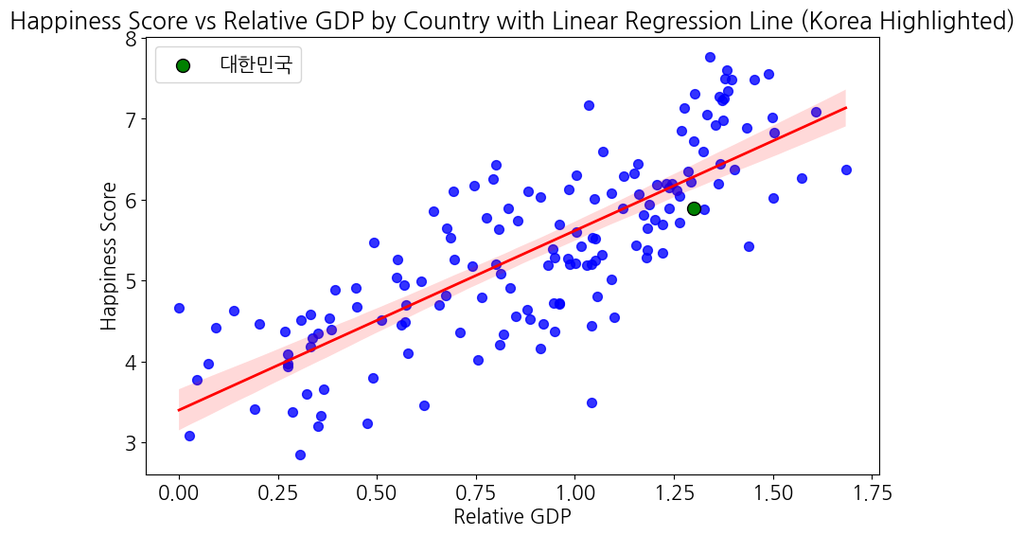

```python
plt.figure(figsize=(10, 6))
df_korea = df[(df['나라명'] == 'South Korea')&(df['년도']==2019)]

plt.figure(figsize=(10, 6))

sns.regplot(x='상대GDP', y='점수', data=df[df['년도']==2019], scatter_kws={'s': 50, 'color': 'blue'}, line_kws={'color': 'red', 'linewidth': 2})

plt.scatter(df_korea['상대GDP'], df_korea['점수'], color='green', s=100, label='대한민국', edgecolor='black', zorder=5)

plt.title('Happiness Score vs Relative GDP by Country with Linear Regression Line (Korea Highlighted)')
plt.xlabel('Relative GDP')
plt.ylabel('Happiness Score')

plt.legend()

plt.show()
```

## 결론: 대한민국은 상대GDP에 비해 행복 점수가 낮은 국가에 해당하며, 최소제곱 1차함수의 신뢰구간 밖에 존재한다는 사실을 알 수 있다.(2019년 기준)